# Educational Indicators 2014 - Dimensions Reduction

## **Unsupervised Learning - Dimensions Reduction**

# **Introduction**

Main goal of this article is to use dimensions reduction methods like MDS, PCA, t-SNE and UMAP. I would like to discuss some of them more precisely. MDS (multidimensional scaling) - is the machine learning approach that used to reduce dimension of the data to show meaningful features of the data. MDS is based on measuring dissimilarities between pairs of elements using euclidean, manhattan and other distances. Method mostly used to reduce dimension of the data in order to be able to plot the data. It is used for example in testing structural hypothesis, exploratory data analysis to help to discover the structure of the data. t-SNE (t-distributed stochastic neighbor embedding) - dimensions reduction algorithm used to visualize the data which is based on Stochastic Neighbor Embedding. This method is able to identify non-linear relationship in data. UMAP is a new machine learning method that is considered to be faster than t-SNE and UMAP is more successful in differentiating each cluster.

# **Review of the Data set**

Data set used for this project was taken from the [dataset repository](https://www.kaggle.com/denisadutca/education-indicators-2014-worldwide). Dataset has information on different educational indicators across both countries and regions.

Indicators:

- Population - **PPT**
- GDP - **GDP**
- Percentage of repeaters in Primary Education - **PRPE**
- Out-of-school children of Primary School - **OOCP**
- Enrollment in Secondary Education - **ESE**
- Enrollment in Primary Education - **EPE**
- Unemployment - **UNEMP**
- Life expectancy at birth - **LEB**
- Theoretical Duration of Primary Education - **TDP**

```r
setwd("C:/Users/daria/OneDrive/Desktop/DSBA 1 semester/1 semestr/Unsupervised Learning")
# loading the data. Working directory was setted before.
library(readr)
```

```r
data = read_csv("Education Indicators 2014.csv", col_names = TRUE)
#View(data)
# dimension of the data
dim(data)
```

```
## [1] 63 10
```

```r
# summary statistics. We can notice that our indicators have different scale.
summary(data)
```

```
##  Country Name            PPT                 GDP                 PRPE
##  Length:63          Min.   :   351706   Min.   :1.399e+09   Min.   : 0.000
##  Class :character   1st Qu.:  4237223   1st Qu.:1.301e+10   1st Qu.: 0.395
##  Mode  :character   Median :  9535079   Median :5.017e+10   Median : 1.380
##                     Mean   : 25216447   Mean   :2.683e+11   Mean   : 3.959
##                     3rd Qu.: 22465060   3rd Qu.:2.655e+11   3rd Qu.: 6.155
##                     Max.   :254454778   Max.   :3.880e+12   Max.   :24.250
##       OOCP              ESE                EPE               UNEMP
##  Min.   :    397   Min.   :   30230   Min.   :   24072   Min.   : 1.000
##  1st Qu.:   4128   1st Qu.:  351824   1st Qu.:  271797   1st Qu.: 4.400
##  Median :  24274   Median :  650516   Median :  773568   Median : 6.200
##  Mean   : 267882   Mean   : 1981848   Mean   : 2492792   Mean   : 8.571
##  3rd Qu.: 186085   3rd Qu.: 1769626   3rd Qu.: 2728357   3rd Qu.: 9.750
##  Max.   :5611792   Max.   :22586956   Max.   :29838440   Max.   :31.000
##       LEB             TDP
##  Min.   :49.70   Min.   :4.000
##  1st Qu.:68.58   1st Qu.:5.000
##  Median :73.50   Median :6.000
##  Mean   :71.68   Mean   :5.524
##  3rd Qu.:77.35   3rd Qu.:6.000
##  Max.   :83.98   Max.   :7.000
```

```r
# Important to know the data type of the columns.
str(data)
```

```
## tibble [63 x 10] (S3: spec_tbl_df/tbl_df/tbl/data.frame)
##  $ Country Name: chr [1:63] "Albania" "United Arab Emirates" "Azerbaijan" "Burundi" ...
##  $ PPT         : num [1:63] 2893654 9086139 9535079 10816860 11231213 ...
##  $ GDP         : num [1:63] 1.32e+10 4.02e+11 7.52e+10 3.09e+09 5.32e+11 ...
##  $ PRPE        : num [1:63] 0.73 0.22 0.16 24.25 2.49 ...
##  $ OOCP        : num [1:63] 7097 14611 22821 69246 6538 ...
##  $ ESE         : num [1:63] 333291 411040 949294 583308 1210112 ...
##  $ EPE         : num [1:63] 195720 409776 517708 2046794 773568 ...
##  $ UNEMP       : num [1:63] 16.1 3.6 5.2 6.9 8.5 1 3.1 11.6 27.9 5.9 ...
##  $ LEB         : num [1:63] 77.8 77.4 70.8 56.7 80.6 ...
##  $ TDP         : num [1:63] 5 5 4 6 6 6 6 4 5 4 ...
##  - attr(*, "spec")=
##   .. cols(
##   ..   `Country Name` = col_character(),
##   ..   PPT = col_double(),
##   ..   GDP = col_double(),
##   ..   PRPE = col_double(),
##   ..   OOCP = col_double(),
##   ..   ESE = col_double(),
##   ..   EPE = col_double(),
##   ..   UNEMP = col_double(),
##   ..   LEB = col_double(),
##   ..   TDP = col_double()
##   .. )
```

```r
#preparing data for analysis
countries_regions = data[,1]
indicators = colnames(data)
indicators = indicators[ 2:length(indicators)]
data = as.matrix(data[,2:ncol(data)])
# normalization of the data, as our indicators have different scales
library(clusterSim)
data_nr<-data.Normalization(data, type="n1",normalization="column")
head(data_nr)
```

```
##             PPT        GDP       PRPE       OOCP        ESE         EPE
## [1,] -0.4945285 -0.4285266 -0.6019239 -0.3381103 -0.4473052 -0.48026373
## [2,] -0.3573432  0.2247060 -0.6970066 -0.3283683 -0.4262094 -0.43550964
## [3,] -0.3473976 -0.3243902 -0.7081928 -0.3177240 -0.2801643 -0.41294360
## [4,] -0.3190016 -0.4455407  3.7830653 -0.2575335 -0.3794677 -0.09324762
## [5,] -0.3098222  0.4431334 -0.2737955 -0.3388350 -0.2093962 -0.35944928
## [6,] -0.3238394 -0.4344282  1.2829503 -0.2562603 -0.2944176 -0.07515498
##            UNEMP        LEB        TDP
## [1,]  1.12859518  0.7219009 -0.5849633
## [2,] -0.74525830  0.6679148 -0.5849633
## [3,] -0.50540505 -0.1078418 -1.7017115
## [4,] -0.25056098 -1.7591119  0.5317848
## [5,] -0.01070773  1.0458175  0.5317848
## [6,] -1.13501982 -1.4281537  0.5317848
```

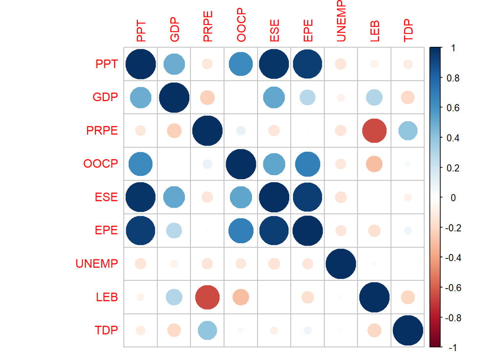

```r
library(corrplot)
library(clusterSim)

corrr<-cor(data_nr, method="pearson")
corrplot(corrr)
```

# **MDS**

```r
library(smacof)
# creating a dissimilarity matrix
dist_data = dist(t(data_nr))
mds = smacofSym(dist_data, ndim = 2 )
library(stats)
mds1<-cmdscale(dist_data, k=2) #k - the maximum dimension of the space
summary(mds1)
```

```
##        V1               V2
##  Min.   :-4.736   Min.   :-5.1146
##  1st Qu.:-4.007   1st Qu.:-2.4754
##  Median :-1.724   Median :-0.8212
##  Mean   : 0.000   Mean   : 0.0000
##  3rd Qu.: 4.931   3rd Qu.: 2.9029
##  Max.   : 5.578   Max.   : 7.5593
```

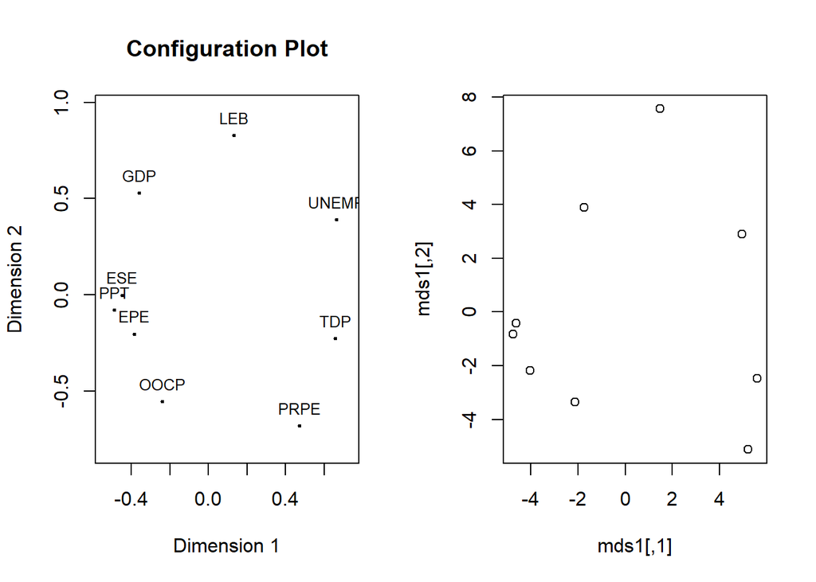

```r
par(mfrow = c(1,2))
plot(mds)
plot(mds1)
```

We can say that EPE, PPT, OOCP, GDP and ESE are in the same group hence providing the same information about education in countries. LEB, UNEMP, TDP and PRPE are possibly outliers in data.

Next step is to check the goodness of MDS fitting the data.

```r
library(smacof)
stress_vector<-randomstress(n=9, ndim=2, nrep=1)
mean(stress_vector)
```

```
## [1] 0.3070712
```

```r
mds$stress
```

```
## [1] 0.1708296
```

```r
ratio<- mds$stress/ mean(stress_vector)
ratio
```

```
## [1] 0.5563192
```

# **t-SNE**

I also would like to demonstrate the results of t-SNE dimensions reduction method. In order to use this method we need to have matrix of distances as well, but allocation of the elements into clusters is calculated with help of t-Student distribution.

One of the feature of t-SNE function are tunable parameters that can change our output significantly.

- **Perplexity** - assumptions about closest neighbors of the data point. In R help it is said that it should be less than (size(dis)-1) /3. In our case it is up to 11 element. Most of the articles are suggesting that perplexity should be in range 5-50, but I think that it depends on the density of data. In case of our data I will use perplexity lower than suggested because our dataset is not large enough.
- **eta** - learning rate. It is suggested that learning rate should be in range (10, 1000).
- **itr** - iteration. Maximum number of iterations to optimize clustering. It should starts from 250 iterations, as algorithm can stop before reaching stability.

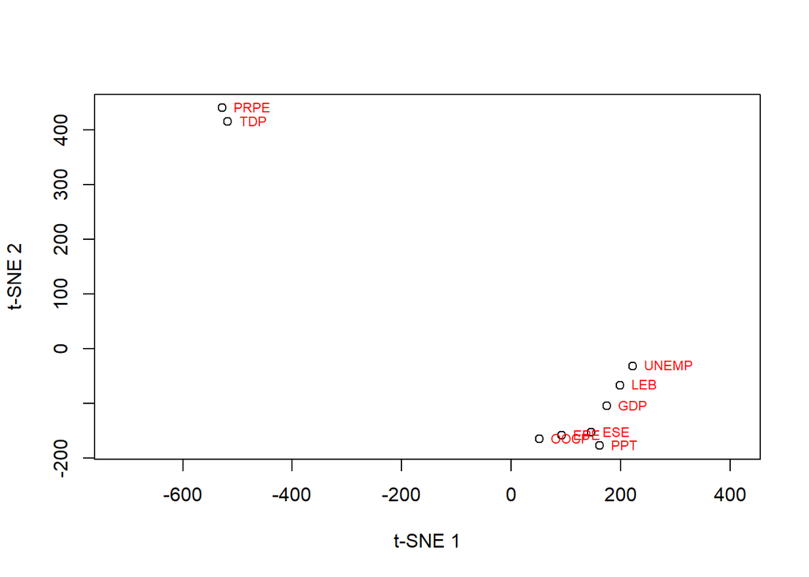

```r
library(labdsv)
tsnee1 = tsne(dist_data, perplexity = 1, eta = 500)

plot(tsnee1)

text(tsnee1$points[,1], tsnee1$points[,2], indicators, cex=0.7, pos=4, col="red")
```

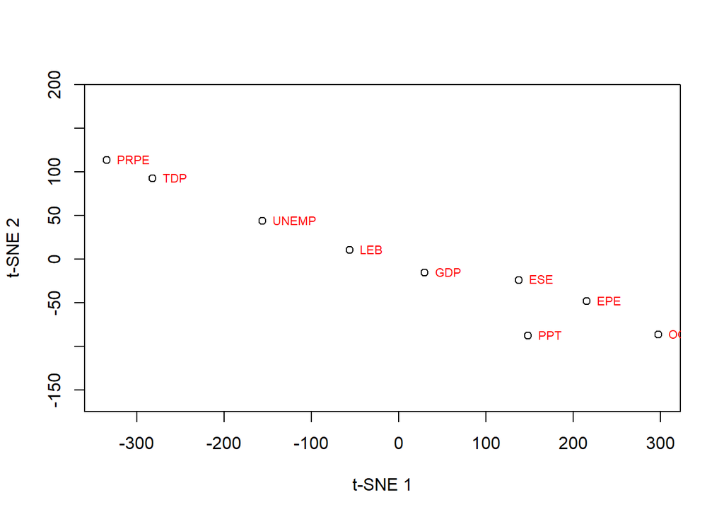

```r
library(labdsv)
tsnee2 = tsne(dist_data, perplexity = 2, eta = 1000)

plot(tsnee2)

text(tsnee2$points[,1], tsnee2$points[,2], indicators, cex=0.7, pos=4, col="red")
```

Having a value of 1 and 2 for hyperparameter, we can notice that TDP and PRPE could create a separate cluster from the rest of the indicators. With the values of the perplexity lower than 5, we can say that local variations are dominating making it difficult to distinguish clusters comparing to first graph. On the first graph we can clearly separate observations into two clusters.

# **PCA**

Before conducting PCA I want to check how many dimensions should be used. To understand this I will make scree plot which describes percentage of explained variances by each of the components.

```r
pca <- prcomp(data_nr, center=FALSE, scale=FALSE)
summary(pca)
```

```
## Importance of components:
##                           PC1    PC2    PC3     PC4     PC5     PC6     PC7
## Standard deviation     1.9012 1.4602 0.9993 0.93621 0.86315 0.58885 0.50724
## Proportion of Variance 0.4016 0.2369 0.1110 0.09739 0.08278 0.03853 0.02859
## Cumulative Proportion  0.4016 0.6385 0.7495 0.84688 0.92966 0.96818 0.99677
##                           PC8     PC9
## Standard deviation     0.1500 0.08102
## Proportion of Variance 0.0025 0.00073
## Cumulative Proportion  0.9993 1.00000
```

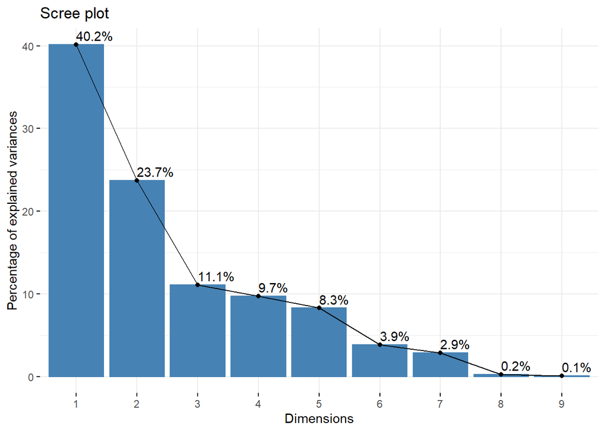

```r
# scree plot
library(factoextra)
fviz_eig(pca, addlabels = TRUE)
```

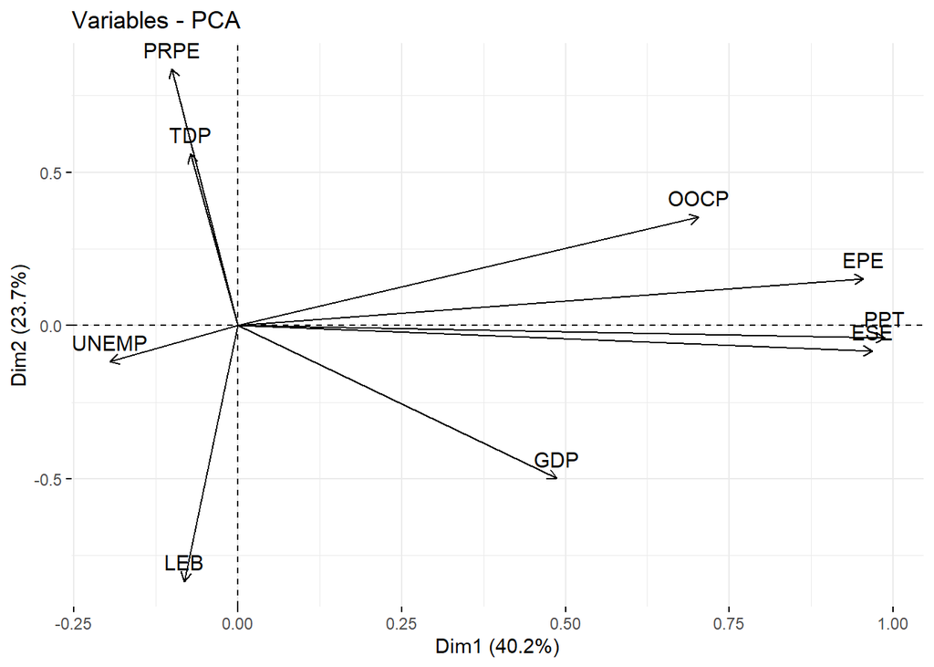

```r
#variable correlation plot
fviz_pca_var(pca)
```

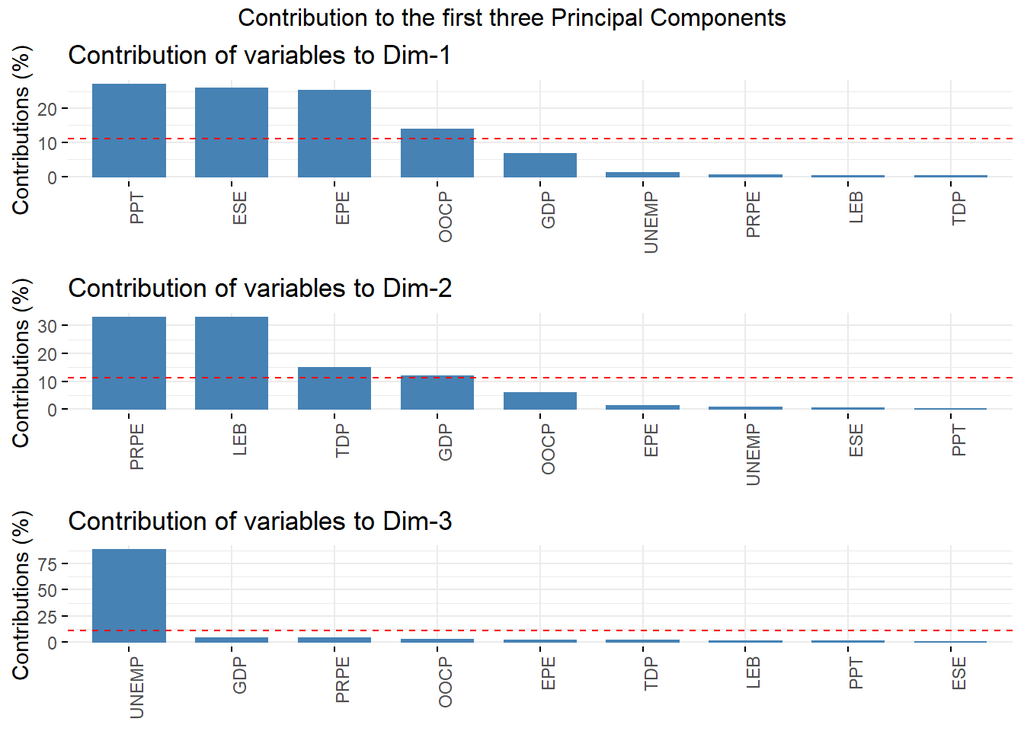

```r
library(gridExtra)
ind<-get_pca_ind(pca)

var<-get_pca_var(pca)
a<-fviz_contrib(pca, "var", axes=1, xtickslab.rt=90)
b<-fviz_contrib(pca, "var", axes=2, xtickslab.rt=90)
c<-fviz_contrib(pca, "var", axes=3, xtickslab.rt=90)
grid.arrange(a,b,c, top='Contribution to the first three Principal Components')
```

## **Complexity**

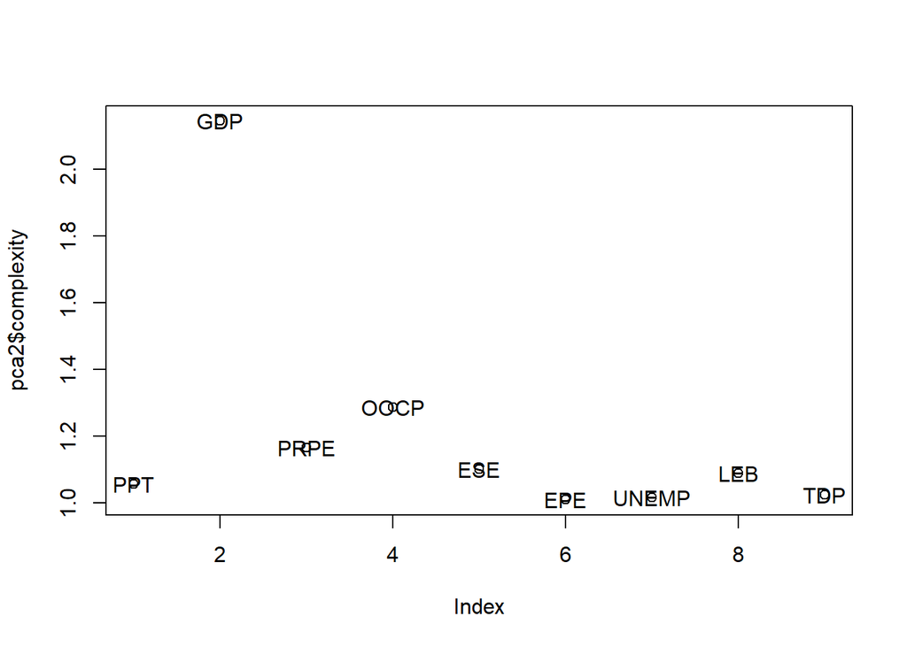

```r
library(psych)
pca2<-principal(data_nr, nfactors=3, rotate="varimax")

plot(pca2$complexity)
text(pca2$complexity, labels = indicators)
```

## **Uniqueness**

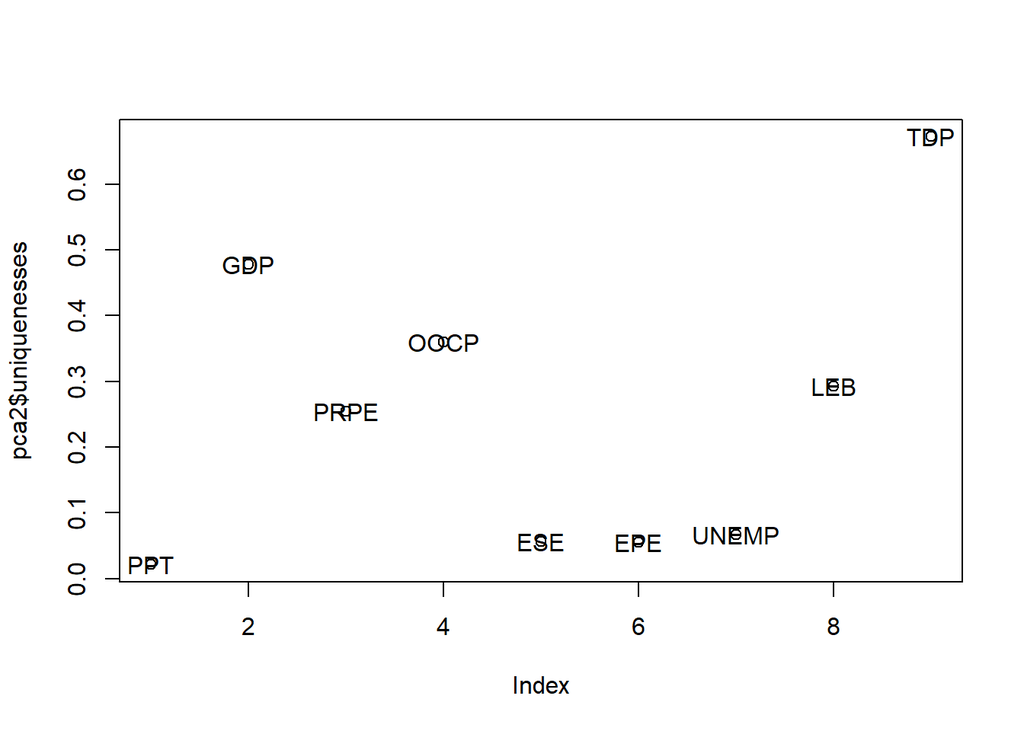

```r
library(psych)

plot(pca2$uniquenesses)
text(pca2$uniquenesses, labels = indicators)
```

PPT, ESE, EPE and UNEMP are considered to have a low level of uniqueness.

# **UMAP**

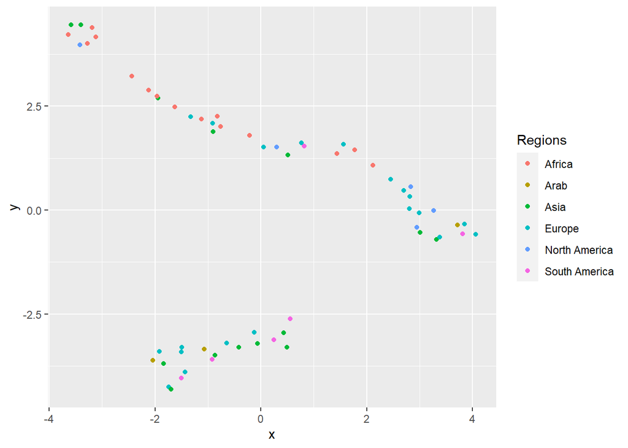

```r
library(umap)
library(ggplot2)
library(clusterSim)

x = read_csv("Book1.csv", col_names = TRUE)
countries = x[,1]
regions = x[, 11]
x_final = as.matrix(x[,2:10])

# we need to normalize data in order to perform clustering to compare the results before and after using UMAP method.
x_nr = data.Normalization(x_final, type = "n1", normalization = "column")

# for umap method we do not need to normalize the data, so we are proceeding with x_final data.
df = umap(x_final)


results = data.frame(x = df$layout[,1],
                     y = df$layout[,2],
                     regions_2 = x[,11])


ggplot(results, aes(x = x, y = y, col = Regions)) + geom_point()
```

## **Clastering**

```r
km1 = eclust(x_nr, "kmeans", hc_metric = "eucledian", k = 3, graph = FALSE)
a1 = fviz_silhouette(km1)
```

```
##   cluster size ave.sil.width
## 1       1   42          0.36
## 2       2   16          0.28
## 3       3    5          0.06
```

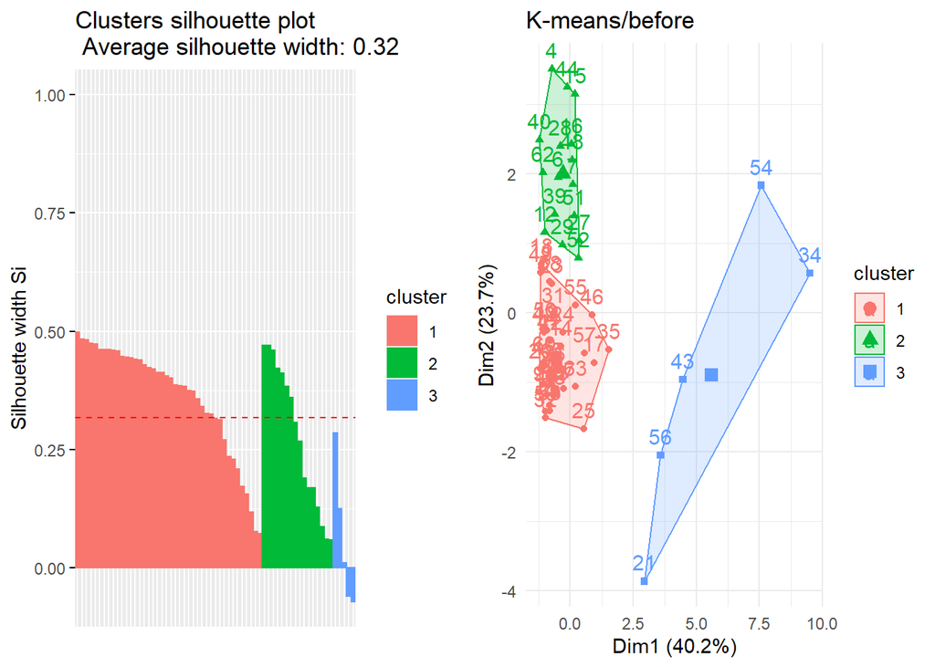

```r
b1 = fviz_cluster(km1, data = data, elipse.type = "convex", main = "K-means/before") + theme_minimal()
grid.arrange(a1, b1, ncol = 2)
```

```r
km2 = eclust(results[,1:2], "kmeans", hc_metric = "eucledian", k = 3, graph = FALSE)
a2 = fviz_silhouette(km2)
```

```
##   cluster size ave.sil.width
## 1       1   20          0.77
## 2       2   23          0.60
## 3       3   20          0.60
```

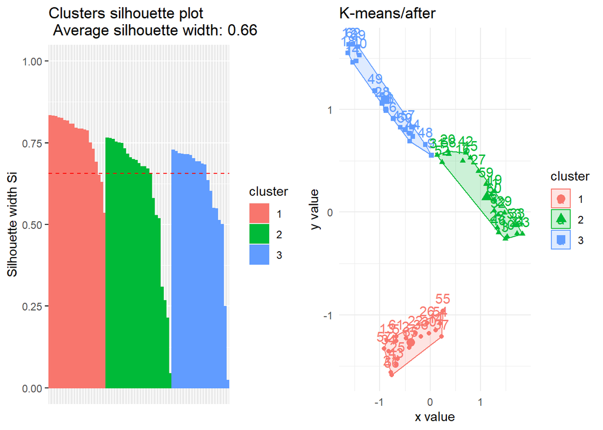

```r
b2 = fviz_cluster(km2, data = data, elipse.type = "convex", main = "K-means/after") + theme_minimal()
grid.arrange(a2, b2, ncol = 2)
```

From the graphs we can see that clustering after dimensions reduction method (UMAP) results are much better taking into consideration silhouette statistics (before - 0.32, after - 0.66).